# Seaborn Examples

### Pair Plot

We can display pair plots across the entire dataset for each pair of numeric attributes

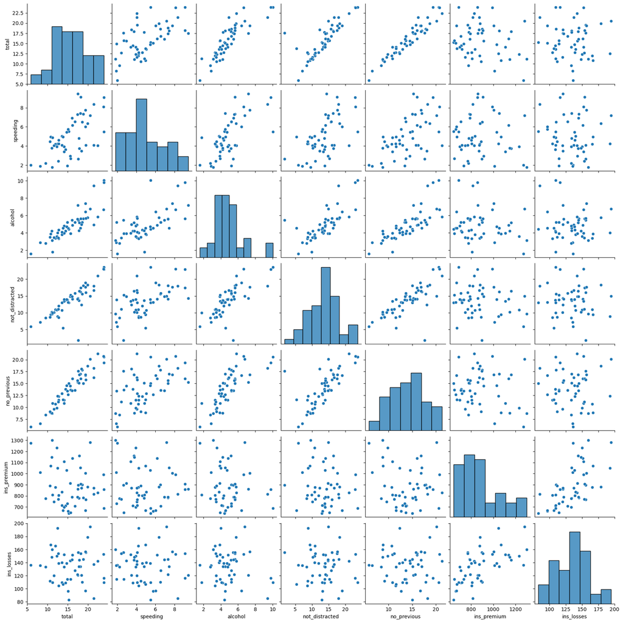

```python
sns.pairplot(data=crashes)
```

We can use hue to have color palettes of categorical data

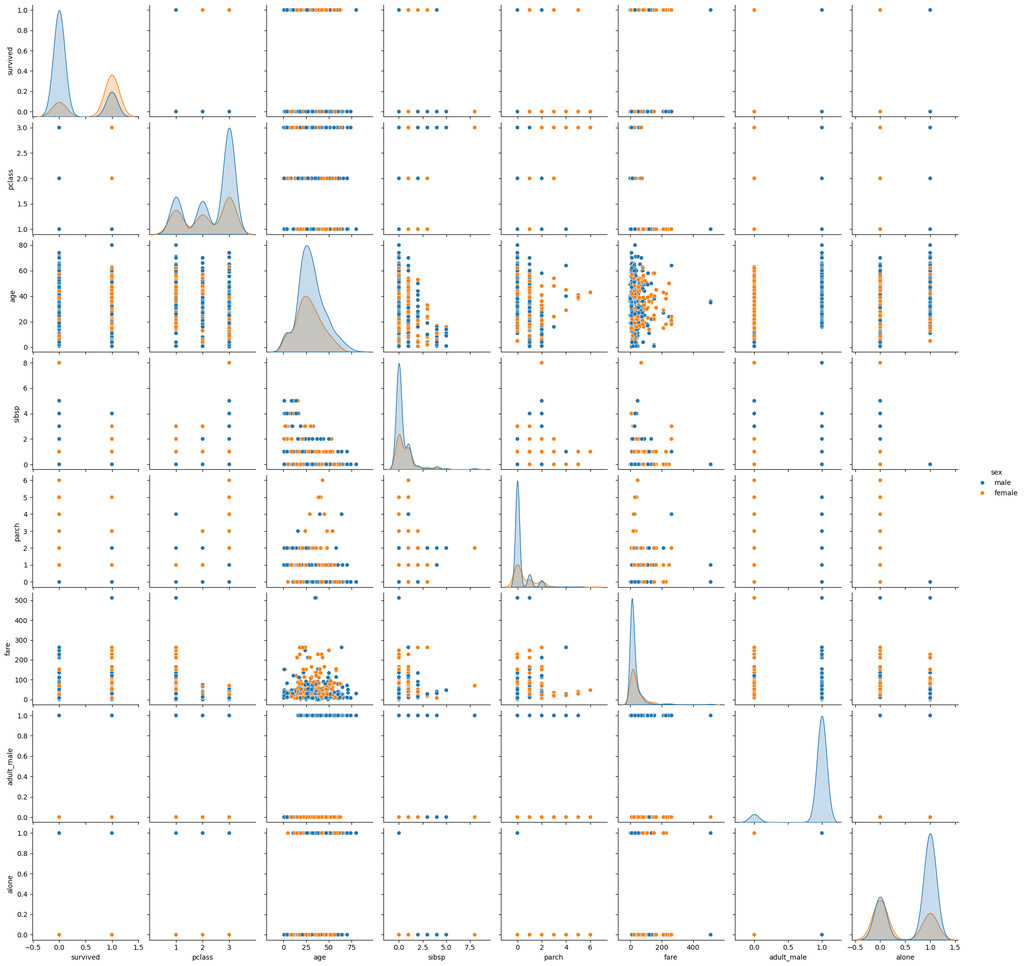

```python
sns.pairplot(data=titanic, hue='sex')
```

[figure not shown]

[figure not shown]

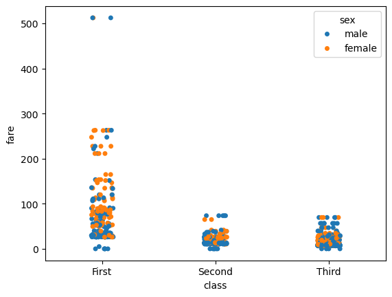

```python
sns.stripplot(data = titanic, x = 'class', y='fare', hue='sex',jitter=True)
```

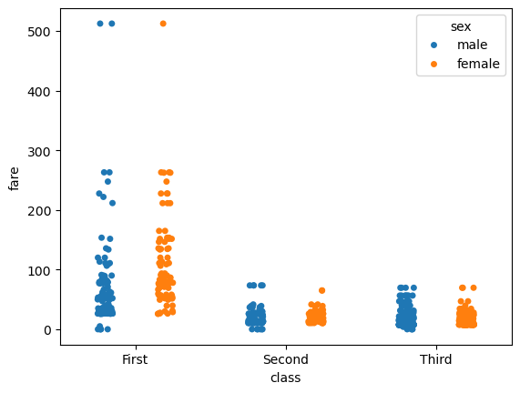

```python
sns.stripplot(data = titanic, x = 'class', y='fare', hue='sex',jitter=True, dodge=True)
```

[figure not shown]

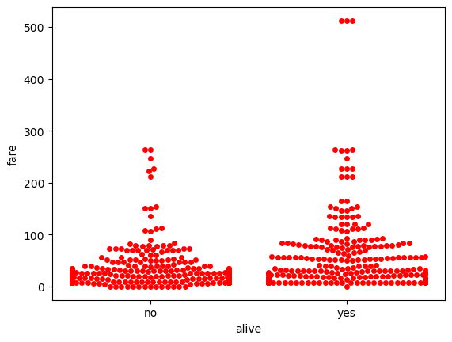

```python
sns.swarmplot(data = titanic, x = 'alive', y='fare', color='red')
```

## Other Feature

### Resizing

We can resize the plot using `height`, `width` and `aspect` parameters

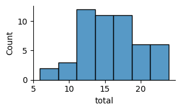

```python
sns.displot(data = crashes, x = 'total', height = 2 , aspect = 1.6)
```

### Styling

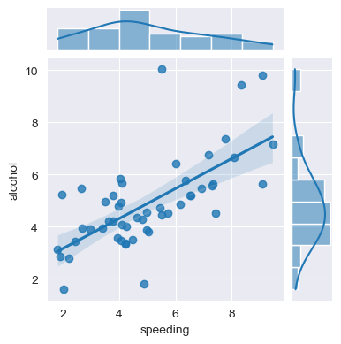

```python
sns.set_style('darkgrid')
sns.jointplot(data=crashes, x='speeding',y='alcohol', kind='reg', height = 4 )
```

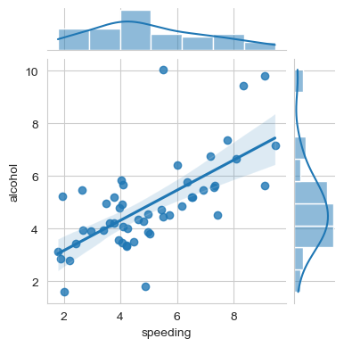

```python
sns.set_style('whitegrid')
sns.jointplot(data=crashes, x='speeding',y='alcohol', kind='reg', height = 4 )
```

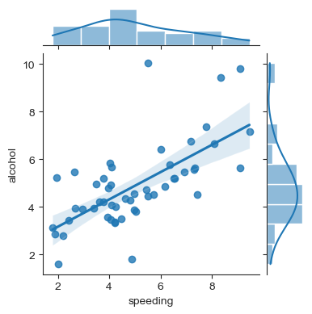

```python
sns.set_style('ticks')
sns.jointplot(data=crashes, x='speeding',y='alcohol', kind='reg', height = 4 )
```

### Label Styling

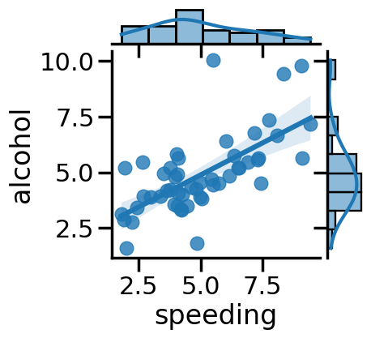

```python
sns.set_context('poster')
sns.jointplot(data=crashes, x='speeding',y='alcohol', kind='reg', height = 4 )
```

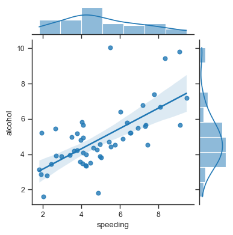

```python
sns.set_context('paper')
sns.jointplot(data=crashes, x='speeding',y='alcohol', kind='reg', height = 4 )
```

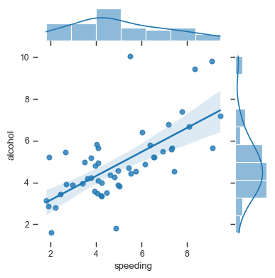

```python
sns.jointplot(data=crashes, x='speeding',y='alcohol', kind='reg', height = 4 )
sns.despine(left=True, bottom=True) # False turns off the boundary
```

### Save Plot

Since seaboarn is built on top of the `matplotlib` package, we can use `matplotlib`'s `savefig()` function to save the generated plot into image file.  
**Note**: The `savefig()` function should come before the `show()` function since the later closes and deletes the image from the memory to save space.

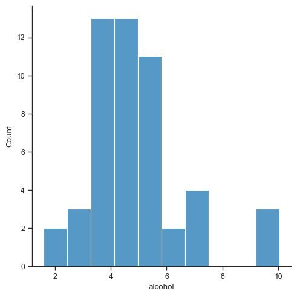

```python
sns.displot(crashes['alcohol'])
plt.savefig('picture.png')
plt.show()
```